# Workshop Mutation 2019

Lee and Martell

February 5, 2019

# workshop.mutation.2019

In this workshop you will learn about the fundamentals of mutation identification in cancer.

```r
library ( cgdsr)
library ( ggplot2)
library(knitr)
library(kableExtra)
library ( dplyr)
source("auxi.R")

# initiate cbioportal

cbiop = CGDS("http://www.cbioportal.org/")
```

# Lets learn how communicate with cbioporta and study what is available.

```r
# Get list of cancer studies at server
studies = getCancerStudies(cbiop)

# lets take a look at it.

k2( head ( studies, 10) , "example list of data available in cbioportal")
```

example list of data available in cbioportal

| cancer_study_id | name | description |
| --- | --- | --- |
| paac_jhu_2014 | Acinar Cell Carcinoma of the Pancreas (Johns Hopkins, J Pathol 2014) | Mutation data from whole exome sequencing of 23 surgically resected pancreatic carcinomas with acinar differentiation. |
| all_stjude_2016 | Acute Lymphoblastic Leukemia (St Jude, Nat Genet 2016) | Whole-genome and/or whole-exome sequencing was performed for ERG-altered B-ALL cases. |
| laml_tcga_pub | Acute Myeloid Leukemia (TCGA, NEJM 2013) | TCGA Acute Myeloid Leukemia, analysis of 200 adult cases; raw data at the <A HREF=“https://tcga-data.nci.nih.gov/tcga/tcgaCancerDetails.jsp?diseaseType=LAML&diseaseName=Acute%20Myeloid%20Leukemia”>NCI… |
| laml_tcga_pan_can_atlas_2018 | Acute Myeloid Leukemia (TCGA, PanCancer Atlas) | Acute Myeloid Leukemia TCGA PanCancer data. The original data is <a href=“https://gdc.cancer.gov/about-data/publications/pancanatlas”>here</a>. The publications are <a href=“https://www.cell.com/pb-as… |
| laml_tcga | Acute Myeloid Leukemia (TCGA, Provisional) | TCGA Acute Myeloid Leukemia; raw data at the <A HREF=“https://tcga-data.nci.nih.gov/”>NCI</A>; source mutation data from <a HREF=“http://gdac.broadinstitute.org/runs/stddata__2016_01_28/data/LAML/2016… |
| acyc_fmi_2014 | Adenoid Cystic Carcinoma (FMI, Am J Surg Pathl. 2014) | Comprehensive genomic profiling of 28 metastatic ACCs. |
| acyc_mda_2015 | Adenoid Cystic Carcinoma (MDA, Clin Cancer Res 2015) | WGS of 21 salivary ACCs and targeted molecular analyses of a validation set (81 patients). |
| acyc_mskcc_2013 | Adenoid Cystic Carcinoma (MSKCC, Nat Genet 2013) | Whole-exome or whole-genome sequencing analysis of 60 ACC tumor/normal pairs |
| acyc_sanger_2013 | Adenoid Cystic Carcinoma (Sanger/MDA, JCI 2013) | Whole exome sequencing of 24 ACCs. |
| acbc_mskcc_2015 | Adenoid Cystic Carcinoma of the Breast (MSKCC, J Pathol. 2015) | Whole exome sequencing of 12 breast AdCCs. |

```r
# ? what do you think each column represents
# ? how do you think we can use this to look for our dataset
# ? what is the "10" for in the function.

# lets find how many unique sets are in here
dim ( studies )
```

```
## [1] 240   3
```

```r
# ? How many studies are there currently in cbioportal

# Find the dataset you want.

# According to the syllabus we are looking for TCGA study on breast cancer from Cell, 2015

# ? How do you think we can locate this based on what we know above
# so lets search for it using the grepl function


breast = studies[ grepl("Breast", studies$name, ignore.case = T ), ]
# ? what is the T for what if you use lower case instead of upper case

k2(breast, "list of breast related studies")
```

list of breast related studies

|  | cancer_study_id | name | description |
| --- | --- | --- | --- |
| 10 | acbc_mskcc_2015 | Adenoid Cystic Carcinoma of the Breast (MSKCC, J Pathol. 2015) | Whole exome sequencing of 12 breast AdCCs. |
| 25 | brca_metabric | Breast Cancer (METABRIC, Nature 2012 & Nat Commun 2016) | The genomic profiles (somatic mutations [targeted sequencing], copy number alterations, and gene expression) of 2509 breast cancers. |
| 26 | breast_msk_2018 | Breast Cancer (MSK, Cancer Cell 2018) | Targeted Sequencing of 1918 tumor and patient-matched normals. |
| 27 | bfn_duke_nus_2015 | Breast Fibroepithelial Tumors (Duke-NUS, Nat Genet 2015) | Whole exome sequencing of 22 phyllodes tumors |
| 28 | brca_bccrc | Breast Invasive Carcinoma (British Columbia, Nature 2012) | Comprehensive profiling of 65 breast cancer samples. Generated by the British Columbia Cancer Research Centre. |
| 29 | brca_broad | Breast Invasive Carcinoma (Broad, Nature 2012) | Comprehensive profiling of 103 breast cancer samples. Generated by the Broad Institute. |
| 30 | brca_sanger | Breast Invasive Carcinoma (Sanger, Nature 2012) | Comprehensive profiling of 100 breast cancer samples. Generated by the Sanger Institute. |
| 31 | brca_tcga_pub2015 | Breast Invasive Carcinoma (TCGA, Cell 2015) | <a href=“http://cancergenome.nih.gov/”>The Cancer Genome Atlas (TCGA)</a> Breast Invasive Carcinoma project. 817 cases (TCGA Cell 2015). |
| 32 | brca_tcga_pub | Breast Invasive Carcinoma (TCGA, Nature 2012) | <a href=“http://cancergenome.nih.gov/”>The Cancer Genome Atlas (TCGA)</a> Breast Invasive Carcinoma project. 825 cases.<br><i>Nature 2012.</i> <a href=“https://tcga-data.nci.nih.gov/docs/publications/… |
| 33 | brca_tcga_pan_can_atlas_2018 | Breast Invasive Carcinoma (TCGA, PanCancer Atlas) | Breast Invasive Carcinoma TCGA PanCancer data. The original data is <a href=“https://gdc.cancer.gov/about-data/publications/pancanatlas”>here</a>. The publications are <a href=“https://www.cell.com/pb… |
| 34 | brca_tcga | Breast Invasive Carcinoma (TCGA, Provisional) | TCGA Breast Invasive Carcinoma; raw data at the <A HREF=“https://tcga-data.nci.nih.gov/”>NCI</A>; source mutation data from <a HREF=“http://gdac.broadinstitute.org/runs/stddata__2016_01_28/data/BRCA/2… |
| 35 | brca_bccrc_xenograft_2014 | Breast cancer patient xenografts (British Columbia, Nature 2014) | Dynamics of genomic clones in breast cancer patient xenografts. |
| 139 | brca_igr_2015 | Mutational profiles of metastatic breast cancer (France, 2016) | Whole-exome sequencing was performed on 216 tumor-normal (blood) pairs from metastatic breast cancer patients who underwent a biopsy in the context of the SAFIR01/SAFIR02 (Unicancer, France), SHIVA (I… |
| 220 | brca_mbcproject_wagle_2017 | The Metastatic Breast Cancer Project (Provisional, October 2018) | The Metastatic Breast Cancer Project is a patient-driven initiative. This study includes genomic data, patient-reported data (pre-pended as PRD), medical record data (MedR), and pathology report data … |

```r
### First BONUS question! try to find if there are other cancer data you might interested in, eg Lung Cancer

# from the table we now know that the study brca_tcga_pub2015 is what we need

brca.study = "brca_tcga_pub2015"

# now that we have a case id we can search to see what types of samples are available AND types of data

mycaselist = getCaseLists(cbiop,brca.study)
# first lets study what is in the case list.
k2 ( head ( mycaselist[ ,c("case_list_id",   "case_list_name",   "case_list_description",    "cancer_study_id"  )], 50), "list of cases for the BRCA CELL 2015 study" )
```

list of cases for the BRCA CELL 2015 study

| case_list_id | case_list_name | case_list_description | cancer_study_id |
| --- | --- | --- | --- |
| brca_tcga_pub2015_3way_complete | All Complete Tumors | All tumor samples that have mRNA, CNA and sequencing data (816 samples) | 1081 |
| brca_tcga_pub2015_methylation_all | All tumor samples with methylation data | All samples with methylation data (817 samples) | 1081 |
| brca_tcga_pub2015_all | All Tumors | All tumor samples (818 samples) | 1081 |
| brca_tcga_pub2015_erpos | ER+ breast tumors | ER+ breast tumors (594 samples) | 1081 |
| brca_tcga_pub2015_erneg | ER- breast tumors | ER- breast tumors (174 samples) | 1081 |
| brca_tcga_pub2015_her2pos | Her2-positive breast tumors | Her2-positive breast tumors (120 samples) | 1081 |
| brca_tcga_pub2015_idc_luma | Invasive Ductal Cancer (Luminal A) | Invasive Ductal Luminal A Breast Tumors (201 samples) | 1081 |
| brca_tcga_pub2015_idc_basal | Invasive Ductal Cancer (PAM50 Basal-like) | PAM50 Basal-like subtype in IDC (107 samples) | 1081 |
| brca_tcga_pub2015_idc_her2 | Invasive Ductal Cancer (PAM50 Her2-enriched) | PAM50 Her2-enriched subtype in IDC (51 samples) | 1081 |
| brca_tcga_pub2015_idc_lumB | Invasive Ductal Cancer (PAM50 Luminal B) | PAM50 Luminal B subtype in IDC (122 samples) | 1081 |
| brca_tcga_pub2015_ilc | Invasive Lobular Cancer | Invasive Lobular Breast Tumors (127 samples) | 1081 |
| brca_tcga_pub2015_ilc_lumA | Invasive Lobular Cancer (Luminal A) | Invasive Lobular Luminal A Breast Tumors (106 samples) | 1081 |
| brca_tcga_pub2015_mixed | Mixed IDC/ILC breast cancer | Mixed ILC/IDC breast cancer (88 samples) | 1081 |
| brca_tcga_pub2015_other | Other histologies breast cancer | Other histologies of breast cancer (112 samples) | 1081 |
| brca_tcga_pub2015_sequenced | Sequenced Tumors | All (Next-Gen) sequenced samples (817 samples) | 1081 |
| brca_tcga_pub2015_freeze | TCGA Freeze 2015 | TCGA second data freeze (817 samples) | 1081 |
| brca_tcga_pub2015_trineg | Triple-negative breast tumors | Triple-negative breast tumors (82 samples) | 1081 |
| brca_tcga_pub2015_cna | Tumor Samples with CNA data | All tumors with CNA data (816 samples) | 1081 |
| brca_tcga_pub2015_methylation_hm27 | Tumor Samples with methylation data (HM27) | All samples with methylation (HM27) data (264 samples) | 1081 |
| brca_tcga_pub2015_methylation_hm450 | Tumor Samples with methylation data (HM450) | All samples with methylation (HM450) data (553 samples) | 1081 |
| brca_tcga_pub2015_mrna | Tumor Samples with mRNA data (Agilent microarray) | All samples with mRNA expression data (421 samples) | 1081 |
| brca_tcga_pub2015_rna_seq_v2_mrna | Tumor Samples with mRNA data (RNA Seq V2) | All samples with mRNA expression data (817 samples) | 1081 |
| brca_tcga_pub2015_rppa | Tumor Samples with RPPA data | Tumors with reverse phase protein array (RPPA) data for about 200 antibodies (673 samples) | 1081 |
| brca_tcga_pub2015_cnaseq | Tumor Samples with sequencing and CNA data | All tumor samples that have CNA and sequencing data (816 samples) | 1081 |

```r
# ? can you tell us what each of the column mean based on what is outputed?
# ? Which data do you think is most relevant this workshop?


# here we see that brca_tcga_pub2015_3way_complete is probably the best to use because it includes
# All Complete Tumors vs something like All tumor samples with methylation data sinc we don't care about methylation in this exercise

case.list.id = "brca_tcga_pub2015_3way_complete"


# ok now using All Complete Tumors lets see if your sample is present.


mysample = mycaselist[ mycaselist$case_list_id == case.list.id, ]$case_ids
mysample = unlist ( strsplit(mysample, " ") )

# ? mysample variable now contains all the TCGA samples in this study, can you check if your sample is exists?

# here is the list
samples
```

```
##  [1] "TCGA-C8-A3M7-01" "TCGA-GM-A2D9-01" "TCGA-BH-A1FL-01"
##  [4] "TCGA-E2-A14Z-01" "TCGA-BH-A1FC-01" "TCGA-AC-A2QJ-01"
##  [7] "TCGA-EW-A1P8-01" "TCGA-E2-A1LE-01" "TCGA-E2-A1LK-01"
## [10] "TCGA-AC-A2FE-01"
```

```r
# here I randomely chose a TCGA ID

mysample[mysample== "TCGA-AC-A2BK-01"]
```

```
## [1] "TCGA-AC-A2BK-01"
```

```r
# here is another way
intersect ( mysample, "TCGA-AC-A2BK-01")
```

```
## [1] "TCGA-AC-A2BK-01"
```

```r
# ? why did we not use grepl this time around?
# hint str ( mysample)

### Now lets check if it matches with what is reported: 816
length ( mysample)
```

```
## [1] 816
```

```r
### Bonus how would you figure out which of these samples are Triple-negative breast tumors.
# hint look at the caselist and work backwards using the intersect function


# Now lets see what information is available for your study
mygeneticprofile = getGeneticProfiles(cbiop,brca.study)
k2 ( mygeneticprofile, "types of data available for chosen case" )
```

types of data available for chosen case

| genetic_profile_id | genetic_profile_name | genetic_profile_description | cancer_study_id | genetic_alteration_type | show_profile_in_analysis_tab |
| --- | --- | --- | --- | --- | --- |
| brca_tcga_pub2015_protein_quantification | Protein expression (RPPA) | Protein expression measured by reverse-phase protein array | 1081 | PROTEIN_LEVEL | false |
| brca_tcga_pub2015_rppa_Zscores | Protein expression Z-scores (RPPA) | Protein expression, measured by reverse-phase protein array, Z-scores | 1081 | PROTEIN_LEVEL | true |
| brca_tcga_pub2015_gistic | Putative copy-number alterations from GISTIC | Putative copy-number calls on 1080 cases determined using GISTIC 2.0. Values: -2 = homozygous deletion; -1 = hemizygous deletion; 0 = neutral / no change; 1 = gain; 2 = high level amplification. | 1081 | COPY_NUMBER_ALTERATION | true |
| brca_tcga_pub2015_mrna | mRNA expression (microarray) | Expression levels for 17157 genes in 590 brca cases (Agilent microarray). | 1081 | MRNA_EXPRESSION | false |
| brca_tcga_pub2015_mrna_median_Zscores | mRNA Expression z-Scores (microarray) | mRNA z-Scores (Agilent microarray) compared to the expression distribution of each gene tumors that are diploid for this gene. | 1081 | MRNA_EXPRESSION | true |
| brca_tcga_pub2015_rna_seq_v2_mrna | mRNA expression (RNA Seq V2 RSEM) | Expression levels for 20532 genes in 1212 brca cases (RNA Seq V2 RSEM). | 1081 | MRNA_EXPRESSION | false |
| brca_tcga_pub2015_rna_seq_v2_mrna_median_Zscores | mRNA Expression z-Scores (RNA Seq V2 RSEM) | mRNA z-Scores (RNA Seq V2 RSEM) compared to the expression distribution of each gene tumors that are diploid for this gene. | 1081 | MRNA_EXPRESSION | true |
| brca_tcga_pub2015_linear_CNA | Relative linear copy-number valuesdata_filename: data_linear_CNA.txt | Relative linear copy-number values for each gene (from Affymetrix SNP6). | 1081 | COPY_NUMBER_ALTERATION | false |
| brca_tcga_pub2015_methylation_hm27 | Methylation (HM27) | Methylation (HM27) beta-values for genes in 343 cases. For genes with multiple methylation probes, the probe most anti-correlated with expression. | 1081 | METHYLATION | false |
| brca_tcga_pub2015_methylation_hm450 | Methylation (HM450) | Methylation (HM450) beta-values for genes in 869 cases. For genes with multiple methylation probes, the probe most anti-correlated with expression. | 1081 | METHYLATION | false |
| brca_tcga_pub2015_mutations | Mutations | Mutation data from whole exome sequencing. | 1081 | MUTATION_EXTENDED | true |

```r
#? based on lecture what information do you think is missing from this table.
# hint, has to do with alignment to a reference

# so looking at that we now know it contains several interesting modalities.  Lets try the mutation
mutation = mygeneticprofile[11, 1]
# ? what does [11, 1] mean
# ? what other modalities do you think may be of interest
cna = mygeneticprofile[3,1]
```

# Now that we have a basic understanding of what is available lets go and download the actual data.

```r
# lets collect this through a loop so not to overwhelm the system
# its important to be mindful of resources when mining data.  We need to play nice and consider the server load.
# ? what do you think we can do to miminize server load?

total = ceiling ( length( cancer.gene)/100  )  *100
mutations = data.frame (   stringsAsFactors = F )
e = 1
for(i in seq(from=200, to=total, by=200)){

    if ( i > length(cancer.gene)){
        i = length(cancer.gene)
    }

    print ( paste ( e, i ))
    temp = getMutationData(cbiop , brca.study, mutation, cancer.gene[e:i])
    e = i + 1
    mutations = rbind ( mutations, temp)

    Sys.sleep (2) # lets give the system a break

}
```

```
## [1] "1 200"
## [1] "201 400"
## [1] "401 600"
## [1] "601 800"
## [1] "801 1000"
## [1] "1001 1200"
## [1] "1201 1400"
## [1] "1401 1600"
## [1] "1601 1800"
```

```r
# create coordinates
mutations$igv = paste ( mutations$chr, mutations$start_position, mutations$end_position, mutations$reference_allele, mutations$variant_allele)

# there is an error in the mutation table.  The links are obsolete.  Here we fix it.
# http://mutationassessor.org/r3

mutations$xvar_link = gsub('getma.org','http://mutationassessor.org/r3', mutations$xvar_link)
mutations$xvar_link_msa = gsub('getma.org','http://mutationassessor.org/r3', mutations$xvar_link_msa )
mutations$xvar_link_pdb = gsub('getma.org','http://mutationassessor.org/r3', mutations$xvar_link_pdb  )
```

# lets study the mutation table

```r
dim ( mutations )
```

```
## [1] 9055   23
```

```r
# lets take a few minutes here to go over the different fields.
names ( mutations )
```

```
##  [1] "entrez_gene_id"              "gene_symbol"
##  [3] "case_id"                     "sequencing_center"
##  [5] "mutation_status"             "mutation_type"
##  [7] "validation_status"           "amino_acid_change"
##  [9] "functional_impact_score"     "xvar_link"
## [11] "xvar_link_pdb"               "xvar_link_msa"
## [13] "chr"                         "start_position"
## [15] "end_position"                "reference_allele"
## [17] "variant_allele"              "reference_read_count_tumor"
## [19] "variant_read_count_tumor"    "reference_read_count_normal"
## [21] "variant_read_count_normal"   "genetic_profile_id"
## [23] "igv"
```

```r
?getMutationData
```

```
## starting httpd help server ... done
```

```r
# ? based on the lecture previously can identify the different mutation_type
# ? based on the lecture previously can you figure out what each of these mean?
# for example which of these is a nonsynonymous substitution
# ? for druggability which one of these do you think its more likely to be useful
unique( mutations$mutation_type)
```

```
##  [1] "Missense_Mutation"      "Nonsense_Mutation"
##  [3] "Splice_Site"            "Frame_Shift_Ins"
##  [5] "Frame_Shift_Del"        "In_Frame_Del"
##  [7] "In_Frame_Ins"           "Translation_Start_Site"
##  [9] "Targeted_Region"        "Nonstop_Mutation"
```

```r
# ? can you guess what is functional_impact_score
k2 ( data.frame ( table ( mutations$functional_impact_score)  ), "impact scores " )
```

impact scores

| Var1 | Freq |
| --- | --- |
|  | 1587 |
| [Not Available] | 51 |
| H | 322 |
| L | 1986 |
| M | 1981 |
| N | 1263 |

```r
# Bonus make sure that your sample has mutations.

nrow ( mutations [ mutations$case_id == "TCGA-AC-A2BK-01", ] )
```

```
## [1] 9
```

```r
# ? if you have more than one sample, say you want to check all 10 samples in the class, how would you do this?

samples
```

```
##  [1] "TCGA-C8-A3M7-01" "TCGA-GM-A2D9-01" "TCGA-BH-A1FL-01"
##  [4] "TCGA-E2-A14Z-01" "TCGA-BH-A1FC-01" "TCGA-AC-A2QJ-01"
##  [7] "TCGA-EW-A1P8-01" "TCGA-E2-A1LE-01" "TCGA-E2-A1LK-01"
## [10] "TCGA-AC-A2FE-01"
```

```r
final =  mutations [ mutations$case_id %in% samples, ]
unique ( final$case_id)
```

```
##  [1] "TCGA-C8-A3M7-01" "TCGA-E2-A1LK-01" "TCGA-EW-A1P8-01"
##  [4] "TCGA-BH-A1FC-01" "TCGA-GM-A2D9-01" "TCGA-E2-A14Z-01"
##  [7] "TCGA-BH-A1FL-01" "TCGA-E2-A1LE-01" "TCGA-AC-A2FE-01"
## [10] "TCGA-AC-A2QJ-01"
```

```r
# so as you can see above there are a total of 10 unique samples.

# lets clear up junk
gc()
```

```
##            used  (Mb) gc trigger  (Mb) max used  (Mb)
## Ncells  3312346 176.9    5684620 303.6  4321904 230.9
## Vcells 27755801 211.8   46191020 352.5 31973754 244.0
```

# Now lets talk a bit about how to identify pathogenic mutations.

## Can you recall some of the things that were mentioned previously?

```r
# One easy approach is to look for "cancer" related genes that had already been implicated in cancer.
# ? how do you think we can do that?

k2 ( cancer.list[17:25, ], "cancer list")
```

cancer list

|  | gene | custom | cosmic | clinvar.all.cancer | FM.combined | ucsf500v2 | civic | broad.target | msk.impact | umich.mioncoseq |
| --- | --- | --- | --- | --- | --- | --- | --- | --- | --- | --- |
| 17 | ABL1 |  | X | X | X | X | X | X | X | X |
| 18 | ABL2 |  | X |  | X | X |  |  |  | X |
| 19 | ABRAXAS1 |  |  | X |  |  |  |  | X |  |
| 20 | ACAN |  |  | X |  |  |  |  |  |  |
| 21 | ACKR3 |  | X |  |  |  |  |  |  |  |
| 22 | ACRV1 |  |  | X |  |  |  |  |  |  |
| 23 | ACSL3 |  | X |  |  |  |  |  |  |  |
| 24 | ACSL6 |  | X |  | X |  |  |  |  |  |
| 25 | ACTA1 |  |  |  |  |  | X |  |  |  |

```r
# ? can you recall what is exome sequencing and why its important?

# lets check this list to make sure genes that are relevant to breast cancer exists

imp = as.character ( cancer.list[grepl("^BRCA|^ATM$|^BARD1$|^CDH1$|^CHEK2$|^NBN$|^NF1$|^PALB2$|^PTEN$", cancer.list$gene), ]$gene )

# ? why did we add ^ in front and $ for only some genes and not others?

k2 ( cancer.list[cancer.list$gene %in% imp, ], "breast cancer genes")
```

breast cancer genes

|  | gene | custom | cosmic | clinvar.all.cancer | FM.combined | ucsf500v2 | civic | broad.target | msk.impact | umich.mioncoseq |
| --- | --- | --- | --- | --- | --- | --- | --- | --- | --- | --- |
| 108 | ATM |  | X | X | X | X | X | X | X | X |
| 129 | BARD1 |  |  | X | X | X |  |  | X |  |
| 159 | BRCA1 |  | X | X | X | X | X | X | X |  |
| 160 | BRCA2 |  | X | X | X | X | X | X | X | X |
| 248 | CDH1 |  | X | X | X | X | X | X | X | X |
| 279 | CHEK2 |  | X | X | X | X | X |  | X |  |
| 1032 | NBN |  | X | X |  | X | X |  | X |  |
| 1052 | NF1 |  | X | X | X | X | X | X | X | X |
| 1128 | PALB2 |  | X | X | X | X | X |  | X | X |
| 1265 | PTEN |  | X | X | X | X | X | X | X | X |

```r
# ? based on this which panel do you think is weakest for breast cancer and why do you think that is the case?

# Bonus: can you check if BRCA is present in any of the mutations we just downloaded?

k2 ( head ( mutations[ grepl("^BRCA", mutations$gene_symbol), ] ), "BRCA gene mutations" )
```

BRCA gene mutations

|  | entrez_gene_id | gene_symbol | case_id | sequencing_center | mutation_status | mutation_type | validation_status | amino_acid_change | functional_impact_score | xvar_link | xvar_link_pdb | xvar_link_msa | chr | start_position | end_position | reference_allele | variant_allele | reference_read_count_tumor | variant_read_count_tumor | reference_read_count_normal | variant_read_count_normal | genetic_profile_id | igv |
| --- | --- | --- | --- | --- | --- | --- | --- | --- | --- | --- | --- | --- | --- | --- | --- | --- | --- | --- | --- | --- | --- | --- | --- |
| 811 | 672 | BRCA1 | TCGA-BH-A0WA-01 | genome.wustl.edu;unc.edu | NA | Splice_Site | NA | X1559_splice | NA | NA | NA | NA | 17 | 41223256 | 41223256 | C | T | 9 | 10 | 30 | 0 | brca_tcga_pub2015_mutations | 17 41223256 41223256 C T |
| 812 | 672 | BRCA1 | TCGA-A1-A0SH-01 | genome.wustl.edu;unc.edu | NA | Nonsense_Mutation | NA | Q934* | NA | http://mutationassessor.org/r3/?cm=var&var=hg19,17,41244748,G,A&fts=all | NA | NA | 17 | 41244748 | 41244748 | G | A | 163 | 47 | 121 | 0 | brca_tcga_pub2015_mutations | 17 41244748 41244748 G A |
| 813 | 672 | BRCA1 | TCGA-A7-A13D-01 | genome.wustl.edu | NA | Missense_Mutation | NA | P1238H | L | http://mutationassessor.org/r3/?cm=var&var=hg19,17,41243835,G,T&fts=all | NA | http://mutationassessor.org/r3/?cm=msa&ty=f&p=BRCA1_HUMAN&rb=1179&re=1368&var=P1238H | 17 | 41243835 | 41243835 | G | T | 16 | 3 | 28 | 0 | brca_tcga_pub2015_mutations | 17 41243835 41243835 G T |
| 814 | 672 | BRCA1 | TCGA-AN-A0XU-01 | genome.wustl.edu;unc.edu | NA | Missense_Mutation | NA | G1788V | M | http://mutationassessor.org/r3/?cm=var&var=hg19,17,41201181,C,A&fts=all | http://mutationassessor.org/r3/pdb.php?prot=BRCA1_HUMAN&from=1756&to=1842&var=G1788V | http://mutationassessor.org/r3/?cm=msa&ty=f&p=BRCA1_HUMAN&rb=1756&re=1842&var=G1788V | 17 | 41201181 | 41201181 | C | A | 46 | 17 | 119 | 0 | brca_tcga_pub2015_mutations | 17 41201181 41201181 C A |
| 815 | 672 | BRCA1 | TCGA-BH-A0DS-01 | genome.wustl.edu;unc.edu | NA | Missense_Mutation | NA | Q1811L | M | http://mutationassessor.org/r3/?cm=var&var=hg19,17,41199695,T,A&fts=all | http://mutationassessor.org/r3/pdb.php?prot=BRCA1_HUMAN&from=1756&to=1842&var=Q1811L | http://mutationassessor.org/r3/?cm=msa&ty=f&p=BRCA1_HUMAN&rb=1756&re=1842&var=Q1811L | 17 | 41199695 | 41199695 | T | A | 131 | 24 | 83 | 0 | brca_tcga_pub2015_mutations | 17 41199695 41199695 T A |
| 816 | 672 | BRCA1 | TCGA-C8-A12T-01 | genome.wustl.edu;unc.edu | NA | Missense_Mutation | NA | D1344H | L | http://mutationassessor.org/r3/?cm=var&var=hg19,17,41243518,C,G&fts=all | NA | http://mutationassessor.org/r3/?cm=msa&ty=f&p=BRCA1_HUMAN&rb=1179&re=1368&var=D1344H | 17 | 41243518 | 41243518 | C | G | 94 | 39 | 238 | 0 | brca_tcga_pub2015_mutations | 17 41243518 41243518 C G |

```r
# lets see how many genes do we have all together
nrow ( cancer.list )
```

```
## [1] 1805
```

```r
### BONUS can you check if your favorite gene is in here?

# Another way we can detect important mutations is to see if other resources are available.
# do you know of any institutions that might have this information.

k2 ( head ( cosmic.70[ grepl("breast",  cosmic.70$description ), ] ), "breast cancer in cosmic")
```

breast cancer in cosmic

chr

start

end

ref

alt

description

igv

2

1

69523

69523

G

T

ID=COSM426644;OCCURENCE=1(breast)

1 69523 69523 G T

10

1

861302

861302

G

A

ID=COSN213381;OCCURENCE=1(breast)

1 861302 861302 G A

30

1

874816

874816

T

ID=COSM1344644;OCCURENCE=1(breast),1(large_intestine),1(liver)

1 874816 874816 - T

42

1

879085

879085

G

T

ID=COSM3806043;OCCURENCE=1(breast)

1 879085 879085 G T

88

1

892292

892292

T

A

ID=COSM3806044;OCCURENCE=1(breast)

1 892292 892292 T A

102

1

897038

897038

G

A

ID=COSM1474247;OCCURENCE=1(breast)

1 897038 897038 G A

```r
# ? what do you think the 70 means?


# lets integrate cosmic into our mutation table

mutations = merge ( mutations, cosmic.70, by="igv", all.x=T, all.y=F )

# ? why do you think all.x = T and all.y=F

# let us find out how many mutations we have that is also found in cosmic

nrow ( mutations[ ! is.na ( mutations$description ),  ] ) / nrow (mutations)
```

```
## [1] 0.7337383
```

```r
# ? wow thats a huge ratio , why do think the ratio is so high?

# BONUS check if cosmic contain BRCA mutations.  This is a good sanity check.

k2 ( head ( mutations[ grepl("^BRCA", mutations$gene_symbol), c("chr.x","start_position","end_position","reference_allele", "variant_allele",
"gene_symbol","case_id","mutation_status","mutation_type","description")] ) )
```

chr.x

start_position

end_position

reference_allele

variant_allele

gene_symbol

case_id

mutation_status

mutation_type

description

2390

13

32905149

32905150

AG

BRCA2

TCGA-A8-A085-01

NA

Frame_Shift_Del

ID=COSM432306,COSM432305;OCCURENCE=1(breast)

2391

13

32907409

32907413

ATCTT

BRCA2

TCGA-E2-A14W-01

NA

Frame_Shift_Del

ID=COSM432307,COSM1477192;OCCURENCE=1(breast)

2392

13

32910551

32910551

G

C

BRCA2

TCGA-AC-A23H-01

NA

Missense_Mutation

ID=COSM3813719,COSM3813718;OCCURENCE=1(breast)

2393

13

32911589

32911589

G

C

BRCA2

TCGA-AC-A23H-01

NA

Missense_Mutation

ID=COSM3813722,COSM3813723;OCCURENCE=1(breast)

2394

13

32911964

32911964

G

C

BRCA2

TCGA-EW-A1PE-01

NA

Missense_Mutation

ID=COSM1477194,COSM1477193;OCCURENCE=1(breast)

2395

13

32912065

32912065

G

C

BRCA2

TCGA-EW-A1PE-01

NA

Missense_Mutation

ID=COSM1477195,COSM1477196;OCCURENCE=1(breast)

```r
# BONUS go to https://cancer.sanger.ac.uk/cosmic and compare results of line 4
# https://cancer.sanger.ac.uk/cosmic/search?q=3813722
# ? does everything match
# ? why do you think the the coordinates are off by 1
# BONUS can you find all BRCA mutation that is Missense_Mutation AND found is cosmic?
# hint, mutations$mutation_type == "Missense_Mutation"
```

# Now that the data has been succesfully donwloaded lets study your breast cancer set.

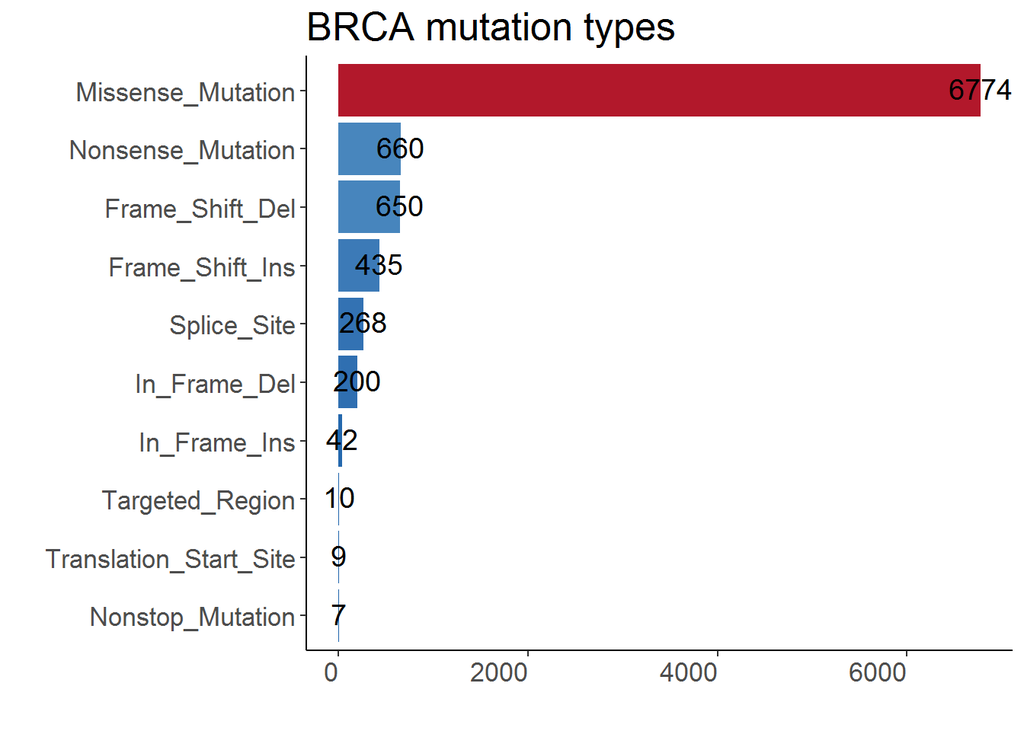

```r
# lets tabulate the types of mutations mostly seen with Breast cancer

mutation.type = data.frame ( table ( mutations$mutation_type))

mutation.type = mutation.type[ order ( mutation.type$Freq), ]
mutation.type$Var1 = factor ( mutation.type$Var1, levels = mutation.type$Var1)

ggplot(mutation.type, aes(Var1,Freq), label=Freq ) +
    geom_bar(aes(fill = Freq), stat="identity", position = "dodge") +
    coord_flip() +
    scale_fill_distiller(palette = "RdBu") + xlab("") + ylab("") +
    theme(strip.text.y = element_text(angle = 0), legend.position="none") +
    geom_text(aes(label=Freq), position=position_dodge(width=0.9), vjust=.4, hjust = .5, size=5) +
    theme(panel.grid.major = element_blank(),
          panel.grid.minor = element_blank(),
          panel.background = element_blank(),
          axis.line = element_line(colour = "black"),
          text = element_text(size=16),  # size of label
          axis.text.x = element_text(angle=0, hjust=1) ) + ggtitle ( "BRCA mutation types")
```

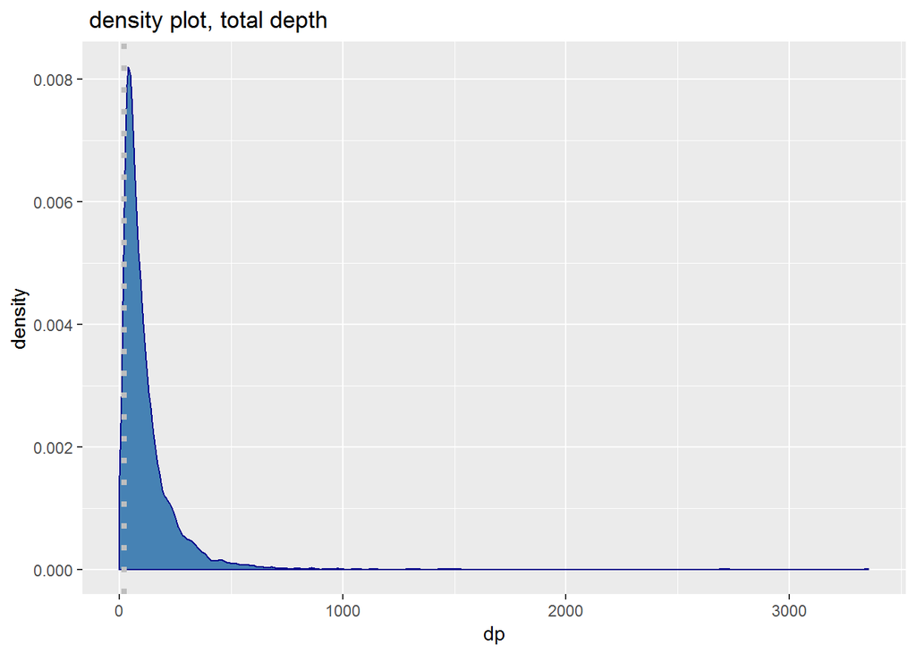

```r
# ? seems like missense mutation is the most recurrent.  Can you think of any way to clean up the data

# ? in the lecture we talked about depth.  So lets calculate this.

mutations$dp = mutations$variant_read_count_tumor + mutations$reference_read_count_tumor

 ggplot(mutations, aes(x=dp)) +
  geom_density( color="darkblue", fill="steelblue" ) + geom_vline(xintercept = 20, linetype="dotted",
                color = "grey", size=1.5) + ggtitle ( " density plot, total depth")
```

```r
# ? by looking at this plot we can see that there is a good amount of mutations that are under 20
# ? how would you remove this?

# before
dim ( mutations )
```

```
## [1] 9055   30
```

```r
# after
mutations = mutations[ mutations$dp > 20, ]
dim (mutations )
```

```
## [1] 8441   30
```

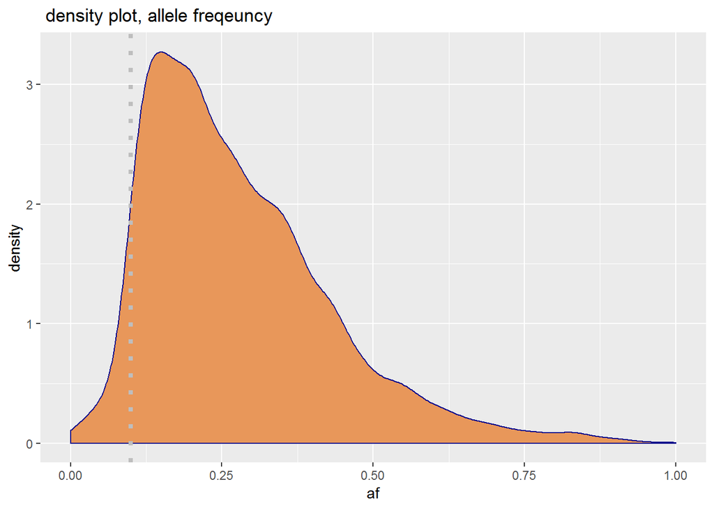

```r
# lets calculate allele freqeuncy here as well
mutations$af = mutations$variant_read_count_tumor / mutations$dp

 ggplot(mutations, aes(x=af)) +
  geom_density( color="darkblue", fill="#e8975a" ) + geom_vline(xintercept = .1, linetype="dotted",
                color = "grey", size=1.5) + ggtitle ( " density plot, allele freqeuncy")
```

```r
# ? what do you think it means when af is higher for a particular mutation
# Bonus pick the top 10 mutations ranked by af

mutations = mutations[ order ( - mutations$af ) , ]

k2 ( head ( mutations, 10) , "top 10 variant ranked by AF")
```

top 10 variant ranked by AF

igv

entrez_gene_id

gene_symbol

case_id

sequencing_center

mutation_status

mutation_type

validation_status

amino_acid_change

functional_impact_score

xvar_link

xvar_link_pdb

xvar_link_msa

chr.x

start_position

end_position

reference_allele

variant_allele

reference_read_count_tumor

variant_read_count_tumor

reference_read_count_normal

variant_read_count_normal

genetic_profile_id

chr.y

start

end

ref

alt

description

dp

af

3132

16 67670628 67670628 G T

10664

CTCF

TCGA-E2-A15T-01

genome.wustl.edu;unc.edu

NA

Nonsense_Mutation

NA

E625*

NA

http://mutationassessor.org/r3/?cm=var&var=hg19,16,67670628,G,T&fts=all

NA

NA

16

67670628

67670628

G

T

0

29

94

0

brca_tcga_pub2015_mutations

16

67670628

67670628

G

T

ID=COSM435539;OCCURENCE=1(breast)

29

1.0000000

6164

3 178916876 178916876 G A

5290

PIK3CA

TCGA-A2-A04P-01

genome.wustl.edu;unc.edu

NA

Missense_Mutation

NA

R88Q

M

http://mutationassessor.org/r3/?cm=var&var=hg19,3,178916876,G,A&fts=all

http://mutationassessor.org/r3/pdb.php?prot=PK3CA_HUMAN&from=31&to=108&var=R88Q

http://mutationassessor.org/r3/?cm=msa&ty=f&p=PK3CA_HUMAN&rb=31&re=108&var=R88Q

3

178916876

178916876

G

A

60

3294

89

0

brca_tcga_pub2015_mutations

3

178916876

178916876

G

A

ID=COSM746,COSM271684;OCCURENCE=9(central_nervous_system),1(stomach),2(cervix),41(endometrium),24(large_intestine),3(urinary_tract),3(pancreas),3(breast)

3354

0.9821109

1659

11 75623074 75623074 C T

7405

UVRAG

TCGA-A7-A4SB-01

genome.wustl.edu;unc.edu

NA

Missense_Mutation

NA

S195F

M

http://mutationassessor.org/r3/?cm=var&var=hg19,11,75623074,C,T&fts=all

NA

http://mutationassessor.org/r3/?cm=msa&ty=f&p=UVRAG_HUMAN&rb=184&re=461&var=S195F

11

75623074

75623074

C

T

19

485

42

0

brca_tcga_pub2015_mutations

11

75623074

75623074

C

T

ID=COSM3810443;OCCURENCE=1(breast)

504

0.9623016

3885

17 7577097 7577097 C A

7157

TP53

TCGA-AC-A2QH-01

genome.wustl.edu;unc.edu

NA

Missense_Mutation

NA

D281Y

M

http://mutationassessor.org/r3/?cm=var&var=hg19,17,7577097,C,A&fts=all

http://mutationassessor.org/r3/pdb.php?prot=P53_HUMAN&from=95&to=289&var=D281Y

http://mutationassessor.org/r3/?cm=msa&ty=f&p=P53_HUMAN&rb=95&re=289&var=D281Y

17

7577097

7577097

C

A

4

63

76

0

brca_tcga_pub2015_mutations

17

7577097

7577097

C

A

ID=COSM11516,COSM214193,COSM3820706,COSM1646814;OCCURENCE=4(lung),2(haematopoietic_and_lymphoid_tissue),1(upper_aerodigestive_tract),2(breast),1(liver),1(kidney),1(endometrium)

67

0.9402985

4103

17 7579311 7579311 C -

7157

TP53

TCGA-B6-A1KF-01

genome.wustl.edu;unc.edu

NA

Splice_Site

NA

X125_splice

NA

NA

NA

NA

17

7579311

7579311

C

2

26

16

0

brca_tcga_pub2015_mutations

17

7579311

7579311

C

ID=COSM318394,COSM318396,COSM318395;OCCURENCE=1(oesophagus),1(lung)

28

0.9285714

8951

9 32543678 32543678 G A

10210

TOPORS

TCGA-A8-A06Q-01

genome.wustl.edu;unc.edu

NA

Missense_Mutation

NA

S282L

M

http://mutationassessor.org/r3/?cm=var&var=hg19,9,32543678,G,A&fts=all

NA

http://mutationassessor.org/r3/?cm=msa&ty=f&p=TOPRS_HUMAN&rb=155&re=386&var=S282L

9

32543678

32543678

G

A

2

26

49

0

brca_tcga_pub2015_mutations

9

32543678

32543678

G

A

ID=COSM455823;OCCURENCE=1(breast)

28

0.9285714

4090

17 7578532 7578532 A T

7157

TP53

TCGA-A1-A0SK-01

genome.wustl.edu;unc.edu

NA

Missense_Mutation

NA

M133K

N

http://mutationassessor.org/r3/?cm=var&var=hg19,17,7578532,A,T&fts=all

http://mutationassessor.org/r3/pdb.php?prot=P53_HUMAN&from=95&to=289&var=M133K

http://mutationassessor.org/r3/?cm=msa&ty=f&p=P53_HUMAN&rb=95&re=289&var=M133K

17

7578532

7578532

A

T

3

38

204

0

brca_tcga_pub2015_mutations

17

7578532

7578532

A

T

ID=COSM11781,COSM437606,COSM437605,COSM437608,COSM437607;OCCURENCE=1(prostate),1(pancreas),3(breast),2(oesophagus),2(stomach),3(haematopoietic_and_lymphoid_tissue)

41

0.9268293

7177

5 180058776 180058776 G -

2324

FLT4

TCGA-AN-A0FX-01

genome.wustl.edu

NA

Frame_Shift_Del

NA

L21Wfs*2

5

180058776

180058776

G

15

190

14

0

brca_tcga_pub2015_mutations

NA

NA

NA

NA

NA

NA

205

0.9268293

1699

11 92507249 92507249 G T

120114

FAT3

TCGA-E9-A1N8-01

genome.wustl.edu;unc.edu

NA

Missense_Mutation

NA

G1413V

H

http://mutationassessor.org/r3/?cm=var&var=hg19,11,92507249,G,T&fts=all

http://mutationassessor.org/r3/pdb.php?prot=FAT3_HUMAN&from=1363&to=1460&var=G1413V

http://mutationassessor.org/r3/?cm=msa&ty=f&p=FAT3_HUMAN&rb=1363&re=1460&var=G1413V

11

92507249

92507249

G

T

25

261

50

0

brca_tcga_pub2015_mutations

11

92507249

92507249

G

T

ID=COSM1475968,COSM1475969;OCCURENCE=1(breast)

286

0.9125874

3909

17 7577121 7577121 G A

7157

TP53

TCGA-EW-A1PC-01

genome.wustl.edu;unc.edu

NA

Missense_Mutation

NA

R273C

M

http://mutationassessor.org/r3/?cm=var&var=hg19,17,7577121,G,A&fts=all

http://mutationassessor.org/r3/pdb.php?prot=P53_HUMAN&from=95&to=289&var=R273C

http://mutationassessor.org/r3/?cm=msa&ty=f&p=P53_HUMAN&rb=95&re=289&var=R273C

17

7577121

7577121

G

A

2

20

34

0

brca_tcga_pub2015_mutations

17

7577121

7577121

G

A

ID=COSM3355991,COSM10659,COSM1645518,COSM99933;OCCURENCE=34(ovary),14(endometrium),3(small_intestine),22(breast),11(skin),5(prostate),111(large_intestine),3(biliary_tract),1(genital_tract),1(adrenal_gland),14(urinary_tract),2(kidney),16(pancreas),20(liver),131(central_nervous_system),23(stomach),2(vulva),25(oesophagus),26(upper_aerodigestive_tract),9(bone),4(thyroid),1(penis),17(lung),5(cervix),25(haematopoietic_and_lymphoid_tissue)

22

0.9090909

```r
# lets further filter the mutations with any af > .1
mutations = mutations[ mutations$af > .1, ]
dim (mutations)
```

```
## [1] 8078   31
```

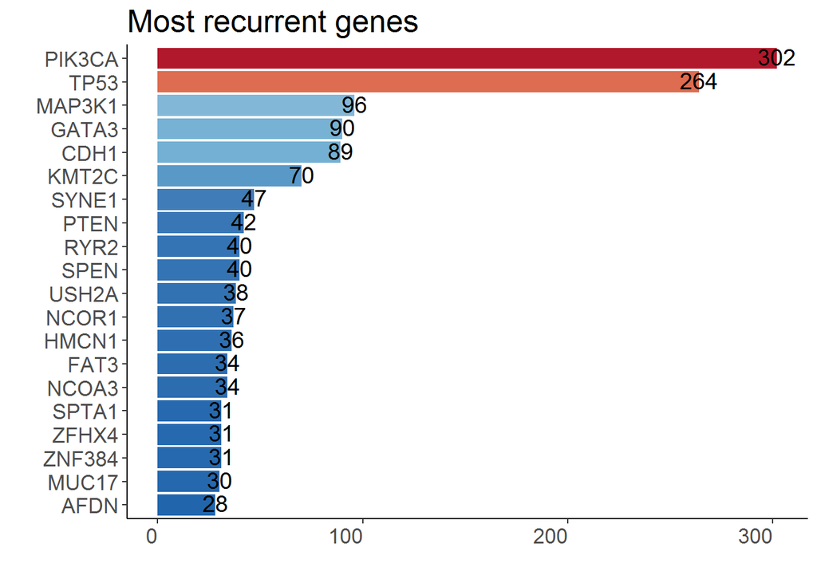

```r
# plot 20 highest recurrent gene mutations

mutation.gene = data.frame ( table ( mutations$gene_symbol))

mutation.gene = mutation.gene[ order ( - mutation.gene$Freq), ]
mutation.gene$Var1 = factor ( mutation.gene$Var1, levels = rev ( mutation.gene$Var1) )

ggplot(mutation.gene [ 1:20, ] , aes(Var1,Freq), label=Freq ) +
    geom_bar(aes(fill = Freq), stat="identity", position = "dodge") +
    coord_flip() +
    scale_fill_distiller(palette = "RdBu") + xlab("") + ylab("") +
    theme(strip.text.y = element_text(angle = 0), legend.position="none") +
    geom_text(aes(label=Freq), position=position_dodge(width=0.9), vjust=.4, hjust = .5, size=5) +
    theme(panel.grid.major = element_blank(),
          panel.grid.minor = element_blank(),
          panel.background = element_blank(),
          axis.line = element_line(colour = "black"),
          text = element_text(size=16),  # size of label
          axis.text.x = element_text(angle=0, hjust=1) ) + ggtitle ( "Most recurrent genes")
```

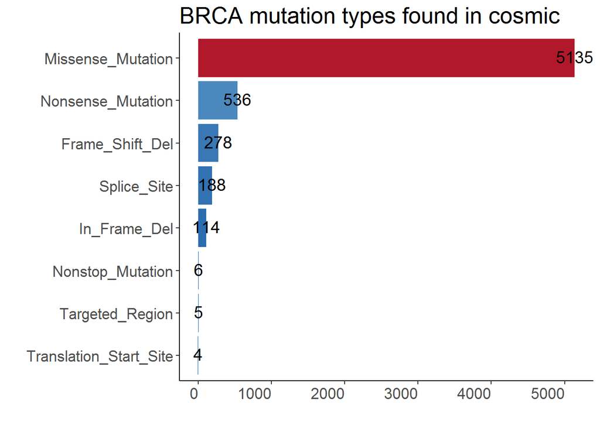

```r
# as mentioned previously one reliable way to look for relevant mutations is to match it against what has been previosly observed and/or study.

cosmic.mutation = mutations [ !is.na(mutations$description), ]

mutation.type = data.frame ( table ( cosmic.mutation$mutation_type))

mutation.type = mutation.type[ order ( mutation.type$Freq), ]
mutation.type$Var1 = factor ( mutation.type$Var1, levels = mutation.type$Var1)

ggplot(mutation.type, aes(Var1,Freq), label=Freq ) +
    geom_bar(aes(fill = Freq), stat="identity", position = "dodge") +
    coord_flip() +
    scale_fill_distiller(palette = "RdBu") + xlab("") + ylab("") +
    theme(strip.text.y = element_text(angle = 0), legend.position="none") +
    geom_text(aes(label=Freq), position=position_dodge(width=0.9), vjust=.4, hjust = .5, size=5) +
    theme(panel.grid.major = element_blank(),
          panel.grid.minor = element_blank(),
          panel.background = element_blank(),
          axis.line = element_line(colour = "black"),
          text = element_text(size=16),  # size of label
          axis.text.x = element_text(angle=0, hjust=1) ) + ggtitle ( "BRCA mutation types found in cosmic")
```

```r
# ? compare the two plots, did anything change?

# based on literature these are some of the genes involved in breast cancer.
imp
```

```
##  [1] "ATM"   "BARD1" "BRCA1" "BRCA2" "CDH1"  "CHEK2" "NBN"   "NF1"
##  [9] "PALB2" "PTEN"
```

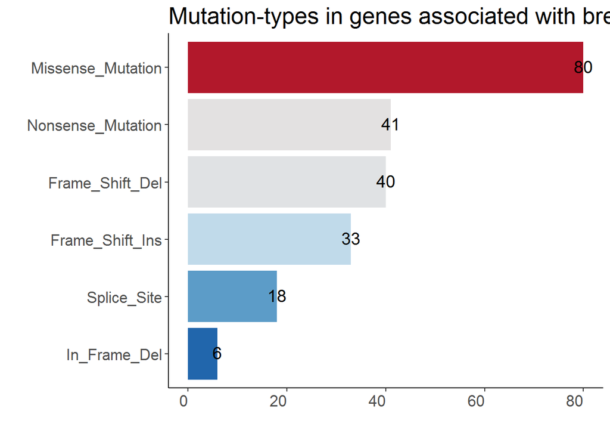

```r
# lets study them and see what types of mutations corresponds most with these genes.

mutation.brca = data.frame ( table ( mutations[ mutations$gene_symbol %in% imp, ] $mutation_type))

mutation.brca = mutation.brca[ order ( mutation.brca$Freq), ]
mutation.brca$Var1 = factor ( mutation.brca$Var1, levels = mutation.brca$Var1)

ggplot(mutation.brca, aes(Var1,Freq), label=Freq ) +
    geom_bar(aes(fill = Freq), stat="identity", position = "dodge") +
    coord_flip() +
    scale_fill_distiller(palette = "RdBu") + xlab("") + ylab("") +
    theme(strip.text.y = element_text(angle = 0), legend.position="none") +
    geom_text(aes(label=Freq), position=position_dodge(width=0.9), vjust=.4, hjust = .5, size=5) +
    theme(panel.grid.major = element_blank(),
          panel.grid.minor = element_blank(),
          panel.background = element_blank(),
          axis.line = element_line(colour = "black"),
          text = element_text(size=16),  # size of label
          axis.text.x = element_text(angle=0, hjust=1) ) + ggtitle ( "Mutation-types in genes associated with breast cancer")
```

```r
# lets assume that we don't know these genes
# ? can you think of a way to find them based on what we have?

# there are many like how we sorted by most frequent above.
# another is to subset by what has already been observe in cosmic

imp.brac = data.frame ( table ( mutations[ grepl( "breast", mutations$description), ]$gene_symbol ) )
imp.brac$fraction = imp.brac$Freq / nrow ( mutations)
imp.brac = imp.brac [ order ( -imp.brac$fraction) , ]

k2 ( head ( imp.brac, 10), "top cosmic genes found in breast cancer")
```

top cosmic genes found in breast cancer

|  | Var1 | Freq | fraction |
| --- | --- | --- | --- |
| 901 | PIK3CA | 295 | 0.0365189 |
| 1238 | TP53 | 242 | 0.0299579 |
| 697 | MAP3K1 | 60 | 0.0074276 |
| 199 | CDH1 | 46 | 0.0056945 |
| 635 | KMT2C | 42 | 0.0051993 |
| 1186 | SYNE1 | 39 | 0.0048279 |
| 1060 | RYR2 | 38 | 0.0047041 |
| 1283 | USH2A | 34 | 0.0042090 |
| 471 | GATA3 | 32 | 0.0039614 |
| 788 | NCOR1 | 29 | 0.0035900 |

```r
# ? how does this compare to our plot above

# both analysis seem to show a lot of overlap eg that TP53 and PIK3CA are important.  Lets breakdown the mutation type a bit more for the top 5

top5 = as.character ( imp.brac$Var1[1:5] )
top5 = mutations[ mutations$gene_symbol %in% top5, ]$amino_acid_change
top5 = data.frame ( table ( top5 ) )
top5 = top5 [ order ( - top5$Freq), ]

# quick hack to add url, will not work with *

top5$url = paste0(url,top5$top5)
k2 ( head ( top5, 20), "top 20 recurrent mutations")
```

top 20 recurrent mutations

|  | top5 | Freq | url |
| --- | --- | --- | --- |
| 136 | H1047R | 110 | https://search.vumc.org/?query=H1047R |
| 95 | E545K | 53 | https://search.vumc.org/?query=E545K |
| 93 | E542K | 29 | https://search.vumc.org/?query=E542K |
| 314 | R175H | 13 | https://search.vumc.org/?query=R175H |
| 236 | N345K | 12 | https://search.vumc.org/?query=N345K |
| 135 | H1047L | 11 | https://search.vumc.org/?query=H1047L |
| 321 | R273H | 9 | https://search.vumc.org/?query=R273H |
| 103 | E726K | 8 | https://search.vumc.org/?query=E726K |
| 315 | R196* | 8 | https://search.vumc.org/?query=R196* |
| 145 | H193R | 6 | https://search.vumc.org/?query=H193R |
| 299 | Q546R | 6 | https://search.vumc.org/?query=Q546R |
| 319 | R248W | 6 | https://search.vumc.org/?query=R248W |
| 317 | R213* | 5 | https://search.vumc.org/?query=R213* |
| 22 | C176F | 4 | https://search.vumc.org/?query=C176F |
| 32 | C420R | 4 | https://search.vumc.org/?query=C420R |
| 88 | E453K | 4 | https://search.vumc.org/?query=E453K |
| 158 | I195T | 4 | https://search.vumc.org/?query=I195T |
| 244 | P127Afs*41 | 4 | https://search.vumc.org/?query=P127Afs*41 |
| 320 | R273C | 4 | https://search.vumc.org/?query=R273C |
| 334 | R342* | 4 | https://search.vumc.org/?query=R342* |

```r
# part of studying mutations is look for clinical significance.  One way to do this is to match your mutations to actionable
# targets


mutations$drug = paste ( mutations$gene_symbol, mutations$amino_acid_change)

action = drug[ drug$match %in% unique ( mutations$drug  ), ]
action.f = c("gene" ,"variant" , "disease", "drugs", "evidence_type",
             "clinical_significance", "evidence_statement", "evidence_civic_url", "gene_civic_url" , "match"
)
k2 ( head ( action[ ,action.f], 20) ,"example of actionable mutations in the BRCA set" )
```

example of actionable mutations in the BRCA set

|  | gene | variant | disease | drugs | evidence_type | clinical_significance | evidence_statement | evidence_civic_url | gene_civic_url | match |
| --- | --- | --- | --- | --- | --- | --- | --- | --- | --- | --- |
| 73 | PIK3CA | E542K | Colorectal Cancer | Regorafenib | Predictive | N/A | PIK3CA mutation status was not predictive of response to regorafenib treatment in patients that had received standard therapy and progressed within 3 months of their last treatment. | https://civic.genome.wustl.edu/links/evidence_items/83 | https://civic.genome.wustl.edu/links/genes/37 | PIK3CA E542K |
| 120 | KRAS | G12V | Colorectal Cancer | Cetuximab | Predictive | Resistance | Cells harboring KRAS G12V mutation were insensitive to cetuximab treatment in isogenic SW48 cells and in a mouse xenograft model. | https://civic.genome.wustl.edu/links/evidence_items/136 | https://civic.genome.wustl.edu/links/genes/30 | KRAS G12V |
| 197 | IDH1 | R132C | Acute Myeloid Leukemia | NA | Diagnostic | Positive | IDH1 R132 mutation is associated with patients of older age, high platelet count during diagnosis, cytogenic normalcy and NPM1 mutation. | https://civic.genome.wustl.edu/links/evidence_items/224 | https://civic.genome.wustl.edu/links/genes/26 | IDH1 R132C |
| 199 | KRAS | G12C | Lung Cancer | NA | Diagnostic | Positive | KRAS G12C occur more frequently in women than men. | https://civic.genome.wustl.edu/links/evidence_items/227 | https://civic.genome.wustl.edu/links/genes/30 | KRAS G12C |
| 200 | KRAS | G12D | Lung Cancer | NA | Diagnostic | Positive | KRAS G12D mutation occurs in never smokers significantly more often than in smokers. | https://civic.genome.wustl.edu/links/evidence_items/228 | https://civic.genome.wustl.edu/links/genes/30 | KRAS G12D |
| 202 | AKT1 | E17K | Breast Cancer | MK-2206 | Predictive | Sensitivity/Response | Breast cancer cell lines with the AKT1 E17K mutation did not show sensitivity to AKT inhibitor MK-2206, unlike cell lines with PIK3CA mutations. | https://civic.genome.wustl.edu/links/evidence_items/231 | https://civic.genome.wustl.edu/links/genes/2 | AKT1 E17K |
| 212 | ERBB2 | L755S | Breast Cancer | Lapatinib | Predictive | Resistance | The L755S mutation was shown to confer resistance to lapatinib in MCF10A cell lines retrovirally transduced with wildtype or mutant ERBB2. | https://civic.genome.wustl.edu/links/evidence_items/241 | https://civic.genome.wustl.edu/links/genes/20 | ERBB2 L755S |
| 223 | PIK3CA | E542K | Colorectal Cancer | Cetuximab,Panitumumab | Predictive | Resistance | The presence of a PIK3CA mutation in exon 9 (such as E542K) or exon 20 were associated with lack of panitumumab or cetuximab response. | https://civic.genome.wustl.edu/links/evidence_items/256 | https://civic.genome.wustl.edu/links/genes/37 | PIK3CA E542K |
| 224 | PIK3CA | H1047R | Colorectal Cancer | Cetuximab,Panitumumab | Predictive | Resistance | In this study, a large cohort of metastatic colorectal cancer patients were treated with anti-epidermal growth factor receptor monoclonal antibodies (cetuximab or panitumumab). KRAS PIK3CA and PTEN we… | https://civic.genome.wustl.edu/links/evidence_items/258 | https://civic.genome.wustl.edu/links/genes/37 | PIK3CA H1047R |
| 244 | ERBB2 | D769H | Breast Cancer | Lapatinib,Neratinib | Predictive | Sensitivity/Response | In MCF10A cell lines, the D769H mutation was shown to be sensitive to neratinib. | https://civic.genome.wustl.edu/links/evidence_items/279 | https://civic.genome.wustl.edu/links/genes/20 | ERBB2 D769H |
| 245 | ERBB2 | D769Y | Breast Cancer | Neratinib | Predictive | Sensitivity/Response | In MCF10A cell lines, the D769Y mutation was shown to be sensitive to neratinib. | https://civic.genome.wustl.edu/links/evidence_items/280 | https://civic.genome.wustl.edu/links/genes/20 | ERBB2 D769Y |
| 247 | ERBB2 | G309A | Breast Cancer | Neratinib | Predictive | Sensitivity/Response | In MCF10A cell lines, the G309A mutation was shown to be sensitive to neratinib. | https://civic.genome.wustl.edu/links/evidence_items/282 | https://civic.genome.wustl.edu/links/genes/20 | ERBB2 G309A |
| 248 | ERBB2 | L755S | Breast Cancer | Neratinib | Predictive | Sensitivity/Response | The L755S mutation showed mild response to neratinib in MCF10A cell lines retrovirally transduced with wildtype or mutant ERBB2. | https://civic.genome.wustl.edu/links/evidence_items/283 | https://civic.genome.wustl.edu/links/genes/20 | ERBB2 L755S |
| 251 | ERBB2 | R678Q | Breast Cancer | Neratinib,Lapatinib | Predictive | Sensitivity/Response | MCF10A cells transduced with ERBB2 harboring an R678Q mutation were sensitive to lapatinib and the irreversible kinase inhibitor neratinib in an matrigel colony forming assay. | https://civic.genome.wustl.edu/links/evidence_items/286 | https://civic.genome.wustl.edu/links/genes/20 | ERBB2 R678Q |
| 253 | ERBB2 | V777L | Breast Cancer | Neratinib | Predictive | Sensitivity/Response | In MCF10A cell lines, the V777L mutation was shown to be sensitive to neratinib. | https://civic.genome.wustl.edu/links/evidence_items/288 | https://civic.genome.wustl.edu/links/genes/20 | ERBB2 V777L |
| 254 | ERBB2 | V842I | Breast Cancer | Neratinib | Predictive | Sensitivity/Response | In MCF10A cell lines, the V842I mutation was shown to be sensitive to neratinib. | https://civic.genome.wustl.edu/links/evidence_items/289 | https://civic.genome.wustl.edu/links/genes/20 | ERBB2 V842I |
| 269 | KRAS | G12D | Non-small Cell Lung Carcinoma | BEZ235 (NVP-BEZ235, Dactolisib),ARRY-142886 | Predictive | Sensitivity/Response | The use of NVP-BEZ235 in conjunction with ARRY-142886, but not as monotherapy, in a lung cancer model with KRAS G12D mutation led to marked tumor regression. | https://civic.genome.wustl.edu/links/evidence_items/305 | https://civic.genome.wustl.edu/links/genes/30 | KRAS G12D |
| 274 | PIK3CA | E542K | Breast Cancer | CH5132799 | Predictive | Sensitivity/Response | Breast cancer cell lines with E542K/E545K mutations showed increased sensitivity to CH5132799 than cells with wild-type PIK3CA gene. | https://civic.genome.wustl.edu/links/evidence_items/310 | https://civic.genome.wustl.edu/links/genes/37 | PIK3CA E542K |
| 275 | PIK3CA | E542K | Breast Cancer | Rapamycin (Sirolimus) | Predictive | Sensitivity/Response | Rapamycin inhibits transformation induced by mutation in PIK3CA. | https://civic.genome.wustl.edu/links/evidence_items/311 | https://civic.genome.wustl.edu/links/genes/37 | PIK3CA E542K |
| 276 | PIK3CA | H1047R | Breast Cancer | CH5132799 | Predictive | Sensitivity/Response | Breast cancer cell lines with H1047R mutation showed increased sensitivity to CH5132799 than cells with wild-type PIK3CA gene. | https://civic.genome.wustl.edu/links/evidence_items/314 | https://civic.genome.wustl.edu/links/genes/37 | PIK3CA H1047R |

```r
# Bonus can you figure out which samples have druggable targets?
#? look at evidence type. Can yo figure out which of these are diagnostic vs targetable?

k2 ( head ( action[action$clinical_significance == "Sensitivity/Response" ,action.f], 20) )
```

|  | gene | variant | disease | drugs | evidence_type | clinical_significance | evidence_statement | evidence_civic_url | gene_civic_url | match |
| --- | --- | --- | --- | --- | --- | --- | --- | --- | --- | --- |
| 202 | AKT1 | E17K | Breast Cancer | MK-2206 | Predictive | Sensitivity/Response | Breast cancer cell lines with the AKT1 E17K mutation did not show sensitivity to AKT inhibitor MK-2206, unlike cell lines with PIK3CA mutations. | https://civic.genome.wustl.edu/links/evidence_items/231 | https://civic.genome.wustl.edu/links/genes/2 | AKT1 E17K |
| 244 | ERBB2 | D769H | Breast Cancer | Lapatinib,Neratinib | Predictive | Sensitivity/Response | In MCF10A cell lines, the D769H mutation was shown to be sensitive to neratinib. | https://civic.genome.wustl.edu/links/evidence_items/279 | https://civic.genome.wustl.edu/links/genes/20 | ERBB2 D769H |
| 245 | ERBB2 | D769Y | Breast Cancer | Neratinib | Predictive | Sensitivity/Response | In MCF10A cell lines, the D769Y mutation was shown to be sensitive to neratinib. | https://civic.genome.wustl.edu/links/evidence_items/280 | https://civic.genome.wustl.edu/links/genes/20 | ERBB2 D769Y |
| 247 | ERBB2 | G309A | Breast Cancer | Neratinib | Predictive | Sensitivity/Response | In MCF10A cell lines, the G309A mutation was shown to be sensitive to neratinib. | https://civic.genome.wustl.edu/links/evidence_items/282 | https://civic.genome.wustl.edu/links/genes/20 | ERBB2 G309A |
| 248 | ERBB2 | L755S | Breast Cancer | Neratinib | Predictive | Sensitivity/Response | The L755S mutation showed mild response to neratinib in MCF10A cell lines retrovirally transduced with wildtype or mutant ERBB2. | https://civic.genome.wustl.edu/links/evidence_items/283 | https://civic.genome.wustl.edu/links/genes/20 | ERBB2 L755S |
| 251 | ERBB2 | R678Q | Breast Cancer | Neratinib,Lapatinib | Predictive | Sensitivity/Response | MCF10A cells transduced with ERBB2 harboring an R678Q mutation were sensitive to lapatinib and the irreversible kinase inhibitor neratinib in an matrigel colony forming assay. | https://civic.genome.wustl.edu/links/evidence_items/286 | https://civic.genome.wustl.edu/links/genes/20 | ERBB2 R678Q |
| 253 | ERBB2 | V777L | Breast Cancer | Neratinib | Predictive | Sensitivity/Response | In MCF10A cell lines, the V777L mutation was shown to be sensitive to neratinib. | https://civic.genome.wustl.edu/links/evidence_items/288 | https://civic.genome.wustl.edu/links/genes/20 | ERBB2 V777L |
| 254 | ERBB2 | V842I | Breast Cancer | Neratinib | Predictive | Sensitivity/Response | In MCF10A cell lines, the V842I mutation was shown to be sensitive to neratinib. | https://civic.genome.wustl.edu/links/evidence_items/289 | https://civic.genome.wustl.edu/links/genes/20 | ERBB2 V842I |
| 269 | KRAS | G12D | Non-small Cell Lung Carcinoma | BEZ235 (NVP-BEZ235, Dactolisib),ARRY-142886 | Predictive | Sensitivity/Response | The use of NVP-BEZ235 in conjunction with ARRY-142886, but not as monotherapy, in a lung cancer model with KRAS G12D mutation led to marked tumor regression. | https://civic.genome.wustl.edu/links/evidence_items/305 | https://civic.genome.wustl.edu/links/genes/30 | KRAS G12D |
| 274 | PIK3CA | E542K | Breast Cancer | CH5132799 | Predictive | Sensitivity/Response | Breast cancer cell lines with E542K/E545K mutations showed increased sensitivity to CH5132799 than cells with wild-type PIK3CA gene. | https://civic.genome.wustl.edu/links/evidence_items/310 | https://civic.genome.wustl.edu/links/genes/37 | PIK3CA E542K |
| 275 | PIK3CA | E542K | Breast Cancer | Rapamycin (Sirolimus) | Predictive | Sensitivity/Response | Rapamycin inhibits transformation induced by mutation in PIK3CA. | https://civic.genome.wustl.edu/links/evidence_items/311 | https://civic.genome.wustl.edu/links/genes/37 | PIK3CA E542K |
| 276 | PIK3CA | H1047R | Breast Cancer | CH5132799 | Predictive | Sensitivity/Response | Breast cancer cell lines with H1047R mutation showed increased sensitivity to CH5132799 than cells with wild-type PIK3CA gene. | https://civic.genome.wustl.edu/links/evidence_items/314 | https://civic.genome.wustl.edu/links/genes/37 | PIK3CA H1047R |
| 279 | TP53 | R175H | Breast Cancer | Doxorubicin | Predictive | Sensitivity/Response | Breast tumors in a mouse model with R172H mutation (homologous to human R175H) are more responsive to doxorubicin than breast tumors with wild type TP53. | https://civic.genome.wustl.edu/links/evidence_items/319 | https://civic.genome.wustl.edu/links/genes/45 | TP53 R175H |
| 552 | AKT1 | E17K | Melanoma | GSK2141795 | Predictive | Sensitivity/Response | A cell line with AKT E17K mutation was found to be sensitive to AKT inhibition with GSK2141795B in this study. | https://civic.genome.wustl.edu/links/evidence_items/707 | https://civic.genome.wustl.edu/links/genes/2 | AKT1 E17K |
| 554 | AKT1 | E17K | Breast Cancer | AZD5363 | Predictive | Sensitivity/Response | In a phase-I study of AZD5363, partial response was observed in 2 patients with breast and ovarian carcinoma, respectively, and AKT1 E17K mutations. While full study results have not yet been publishe… | https://civic.genome.wustl.edu/links/evidence_items/709 | https://civic.genome.wustl.edu/links/genes/2 | AKT1 E17K |
| 555 | PIK3CA | E545K | Breast Cancer | MK-2206,Pictilisib | Predictive | Sensitivity/Response | PIK3CA E545K mutation increased sensitivity to AKT inhibitor MK-2206 and PI3K inhibitor GDC-0941 in a breast cancer cell line model. | https://civic.genome.wustl.edu/links/evidence_items/710 | https://civic.genome.wustl.edu/links/genes/37 | PIK3CA E545K |
| 576 | IDH1 | R132C | Acute Myeloid Leukemia | GSK321 | Predictive | Sensitivity/Response | Newly developed allosteric inhibitors (GSK321) of IDH1 led to granulocytic differentiation in-vitro and in-vivo. | https://civic.genome.wustl.edu/links/evidence_items/732 | https://civic.genome.wustl.edu/links/genes/26 | IDH1 R132C |
| 636 | KRAS | G12V | Non-small Cell Lung Carcinoma | PD0332991 | Predictive | Sensitivity/Response | In vivo studies confirmed the activity of PD0332991 (CDK4 inhibitor) on KRAS G12V mutant tumors. 17% (2/12) of mice treated with PD0332991 developed detectable lesions, whereas 75% of mice (3/4) treat… | https://civic.genome.wustl.edu/links/evidence_items/795 | https://civic.genome.wustl.edu/links/genes/30 | KRAS G12V |
| 773 | KRAS | G12D | Pancreatic Carcinoma | MK-2206 | Predictive | Sensitivity/Response | Among 33 patients treated with pan-AKT inhibitor MK-2206 in this phase 1 study, one patient with pancreatic adenocarcinoma and PTEN loss and a KRAS G12D mutation experienced a decrease of approximatel… | https://civic.genome.wustl.edu/links/evidence_items/937 | https://civic.genome.wustl.edu/links/genes/30 | KRAS G12D |
| 970 | KRAS | G12C | Non-small Cell Lung Carcinoma | Docetaxel,Selumetinib (AZD6244) | Predictive | Sensitivity/Response | 83 patients from a phase II trial (docetaxel + placebo or MEK1/2 inhibitor selumetinib) with KRAS mutant tumors were retrospectively assessed for differences in OS, PFS, ORR and change in tumor size a… | https://civic.genome.wustl.edu/links/evidence_items/1142 | https://civic.genome.wustl.edu/links/genes/30 | KRAS G12C |

# HW at this point please use your own TCGA ID, study it using what you learn above. Assess QC on your sample, study what genes are most common and which if any are targetable.

```r
# here is example where I chose, myid = "TCGA-C8-A131-01"
myid = "TCGA-C8-A131-01"

actionid = drug[ drug$match %in% unique ( mutations[mutations$case_id == myid, ]  $drug  ), ]

actionid = actionid %>% dplyr::group_by(variant) %>%
        dplyr::summarise(
            gene = paste(unique ( gene ), collapse = "," ) ,
            disease = paste(unique ( disease ), collapse = "," ),
            clinical_significance =  paste(unique ( clinical_significance ), collapse = "," ),
            drugs = paste(unique ( drugs ), collapse = "," )

        ) %>%
        data.frame()
k2( actionid, myid)
```

TCGA-C8-A131-01

| variant | gene | disease | clinical_significance | drugs |
| --- | --- | --- | --- | --- |
| G12V | KRAS | Colorectal Cancer,Non-small Cell Lung Carcinoma,Cancer,Lung Cancer | Resistance,Sensitivity/Response,Poor Outcome | Cetuximab,PD0332991,NA,Docetaxel,Selumetinib (AZD6244),Crizotinib,Selumetinib (AZD6244),BEZ235,Panitumumab,Gefitinib,Regorafenib,Panitumumab,Cetuximab |
| H1047R | PIK3CA | Colorectal Cancer,Breast Cancer,Head And Neck Cancer,Lung Adenocarcinoma,Head And Neck Squamous Cell Carcinoma,Her2-receptor Positive Breast Cancer,Thyroid Cancer,Non-small Cell Lung Carcinoma | Resistance,Sensitivity/Response | Cetuximab,Panitumumab,CH5132799,Panitumumab,Cetuximab,BEZ235 (NVP-BEZ235, Dactolisib),Cetuximab,BEZ235 (NVP-BEZ235, Dactolisib),BYL719 (Alpelisib),Taselisib (GDC-0032),AZD5363,Trastuzumab,AZD5363,Lapa… |
| R175H | TP53 | Breast Cancer,Stomach Carcinoma,Cancer | Sensitivity/Response,Poor Outcome,Resistance | Doxorubicin,NA,EAP Protocol,AMGMDS3 |